# Базовые операции с таблицами, векторами и списками в R

2017-09-07

# Введение

Процесс анализа данных

В этом блокноте показаны самые необходимые приемы обработки данных в R. Поясняется работа с базовыми типами данных R - векторами, списками и таблицами данных, а также загрузка данных из Excel.

```r
library(tidyverse)
library(readxl) # считывание данных в формате Excel
library(stringr) # операции со строками

# Раскомментируйте и запустите следующие команды,
# если у вас не ставится tidyverse

#library(dplyr)
#library(ggplot2)
#library(tidyr)
```

Если у вас не ставится пакет `tidyverse`, то для работы с этим блокнотом потребуется установить и загрузить пакеты: `ggplot2`, `dplyr`, `readxl`, `stringr`.

# Как загрузить данные из Excel

Для загрузки данных в форматах `xlsx` и `xls` в R используется пакет функция `read_excel()` из пакета `readxl`. Поскольку в Excel поддерживается разделение данных по типам, обычно возникает меньше проблем при загрузке, чем с текстовыми файлами.

Желательно, чтобы в Excel на листе, откуда предполагается читать данные, содержалась только таблица данных, начиная с первой строки.

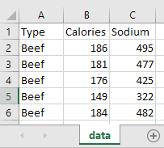

Правильная структура рабочего листа

При необходимости вы можете выбрать нужный лист и диапазон для чтения - см `?read_excel`

```r
# Загрузить лист с именем 'data' из книги:
hotdogs <- read_excel('data/hotdogs.xlsx', sheet = 'data')
```

Обратите внимание, что мы используем **относительный путь** к файлу данных. Текущей директорией для блокнота является та, где он находится. Файл `hotdogs.xlsx` находится на уровень ниже - в подпапке `data`.

Загруженные данные помещены в переменную `hotdogs`. Данные - это результаты лабораторного анализа хот-догов с разным типом начинки: содержание натрия (`Sodium`) и пищевая ценность (`Calories`).

# Предварительное знакомство с данными

## Просмотр таблицы

Мы можем проконтролировать результат загрузки, выведя небольшую часть данных в начале таблицы с помощью функции `head()`. При необходимости можно посмотреть также конец таблицы с помощью `tail()`, или всю таблицу целиком в отдельном окне - с помощью `View()`.

В RStudio проще всего вместо открыть таблицу для просмотра, нажав на иконку таблицы в панели Environment.

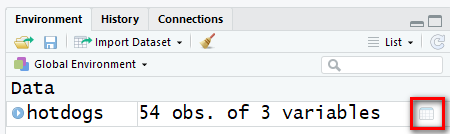

Просмотр таблицы через панель Environment

Посмотрим, какие данные загрузились:

```r
head(hotdogs, n = 5) # посмотрим первые 5 строк
```

```
## # A tibble: 5 x 3
##    Type Calories Sodium
##   <chr>    <dbl>  <dbl>
## 1  Beef      186    495
## 2  Beef       NA    477
## 3  Beef      176    425
## 4  Beef      149    322
## 5  Beef      184    482
```

## Структура таблицы

Также можно изучить структуру таблицы с помощью функции `str()`. Эта функция позволяет видеть структуру любого объекта в R.

```r
str(hotdogs)
```

```
## Classes 'tbl_df', 'tbl' and 'data.frame':    54 obs. of  3 variables:
##  $ Type    : chr  "Beef" "Beef" "Beef" "Beef" ...
##  $ Calories: num  186 NA 176 149 184 190 158 139 175 148 ...
##  $ Sodium  : num  495 477 425 322 482 887 370 322 479 375 ...
```

При работе с данными полезно знать их размерность. Для этого можно использовать функцию `dim()`, которая выводит количество строк и столбцов таблицы:

```r
dim(hotdogs)
```

```
## [1] 54  3
```

Отдельно получить количество строк и столбцов таблицы можно с помощью функций: `nrow()` и `ncol()`.

```r
nrow(hotdogs)
```

```
## [1] 54
```

## Просмотр и изменение имен столбцов таблицы

Еще одна полезная функция - `names()`. Эта функция позволяет вывести имена столбцов таблицы.

```r
names(hotdogs)
```

```
## [1] "Type"     "Calories" "Sodium"
```

С помощью функции `names()` можно не только посмотреть, но и изменить имена столбцов таблицы. Например, мы можем преобразовать сразу все имена столбцов к нижнему регистру:

```r
names(hotdogs) <- str_to_lower(names(hotdogs))
head(hotdogs)
```

```
## # A tibble: 6 x 3
##    type calories sodium
##   <chr>    <dbl>  <dbl>
## 1  Beef      186    495
## 2  Beef       NA    477
## 3  Beef      176    425
## 4  Beef      149    322
## 5  Beef      184    482
## 6  Beef      190    887
```

## Распределение значений в столбцах

После загрузки данных необходимо изучить распределение значений в каждом из них. Целью этой операции является выявление проблем в данных - выбросов, некорректных значений и пропусков. Кроме того, можно оценить форму распределения, степень его асимметричности.

Для просмотра статистической сводки по всем столбцам таблицы можно воспользоваться функцией `summary()`.

```r
summary(hotdogs)
```

```
##      type              calories         sodium
##  Length:54          Min.   :  9.0   Min.   :144.0
##  Class :character   1st Qu.:131.8   1st Qu.:367.5
##  Mode  :character   Median :143.5   Median :405.0
##                     Mean   :142.8   Mean   :431.2
##                     3rd Qu.:172.2   3rd Qu.:506.2
##                     Max.   :195.0   Max.   :887.0
##                     NA's   :2       NA's   :2
```

В этом наборе данных мы видим, что имеются по 2 пропущенных значения в каждом числовом столбце.

К сожалению, `summary()` не выводит информацию о пропущенных значениях в текстовых переменных.

Размах переменной `sodium` (содержание натрия) в 4 раза выше, чем размах переменной `calories`. Распределение этой переменной имеет небольшую асимметрию, т.к. среднее смещено вправо относительно медианы.

# Работа с таблицами

Наиболее востребованными операциями с таблицей данных доступ к столбцу, вычисление новых столбцов и отбор данных.

## Доступ к столбцу таблицы и векторизованные операции

Если для анализа необходимы данные одного из столбцов таблицы - можно обратиться к столбцу, указав его после имени таблицы через `$`:

```r
# Калорийность в исходных единицах (ккал):
hotdogs$calories
```

```
##  [1] 186  NA 176 149 184 190 158 139 175 148 152 111 141 153 190  NA 131
## [18] 149 135 132 173 191 182 190 172 147 146 139 175 136 179 153 107 195
## [35] 135 140 138 129 132 102 106  94 102  87   9 107 113 135 142  86 143
## [52] 152 146 144
```

В результате извлечения одного столбца таблицы получается **вектор** - еще один базовый тип данных R. Вектор содержит элементы одного типа данных. Все операции с вектором выполняются одновременно для всех его элементов (такие операции называются **векторизованными**).

В качестве примера пересчитаем пищевую ценность из ккал в кДж:

```r
# Калорийность в кДж
round(hotdogs$calories * 4.184)
```

```
##  [1] 778  NA 736 623 770 795 661 582 732 619 636 464 590 640 795  NA 548
## [18] 623 565 552 724 799 761 795 720 615 611 582 732 569 749 640 448 816
## [35] 565 586 577 540 552 427 444 393 427 364  38 448 473 565 594 360 598
## [52] 636 611 602
```

### Недопустимые символы в именах столбцов

Рекомендуем использовать в именах столбцов только латинские буквы, подчеркивания и цифры. Не стоит использовать пробелы, русские буквы и служебные символы. Если вам все же необходимо работать с таблицей, имена которые содержат эти символы, то такие имена нужно заключать между знаками апострофа.

Например, если бы потребовалось обратиться к полю таблицы с именем: `неудачное имя`, то пришлось бы обращаться к нему так:

```
table$`неудачное имя`
```

## Вычисление нового столбца

В предыдущем примере мы вывели результаты расчета на экран, но ими не получится пользоваться в дальнейшем, т.к. результаты нигде не сохранены.

При вычислениях на основе табличных данных в большинстве случаев необходимо сохранить результаты в ту же таблицу, в виде новых столбцов.

Рассмотрим два способа вычисления новых столбцов

### Вычисление столбца в базовом R

Запись с `$` позволяет не только извлекать, но и добавлять новые столбцы в таблицу. В качестве примера вычислим относительное содержание натрия в хот-догах. К сожалению, в таблице нет массы, поэтому мы не сможем вычислить процентное содержание. Однако в качестве показателя размера хот-дога можем воспользоваться калорийностью. Можно предположить, что более калорийные хот-доги должны быть более тяжелыми.

```r
# Соотношение Na и калорийности:
hotdogs$sodium_ratio = hotdogs$sodium / hotdogs$calories

head(hotdogs)
```

```
## # A tibble: 6 x 4
##    type calories sodium sodium_ratio
##   <chr>    <dbl>  <dbl>        <dbl>
## 1  Beef      186    495     2.661290
## 2  Beef       NA    477           NA
## 3  Beef      176    425     2.414773
## 4  Beef      149    322     2.161074
## 5  Beef      184    482     2.619565
## 6  Beef      190    887     4.668421
```

### Вычисление столбца с помощью dplyr

Недостатком записи с `$` является необходимость каждый раз указывать в качестве префикса имя таблицы. Это загромождает формулы и делает расчет менее понятным. Поэтому мы рассмотрим более удобный подход, основанный на использовании функции `mutate()` пакета `dplyr`. Преимущества - возможность писать имена столбцов без префикса и возможность рассчитать сразу несколько столбцов.

```r
hotdogs <- mutate(hotdogs,
                  sodium_ratio = sodium / calories,
                  kilojoules = calories * 4.184)
head(hotdogs)
```

```
## # A tibble: 6 x 5
##    type calories sodium sodium_ratio kilojoules
##   <chr>    <dbl>  <dbl>        <dbl>      <dbl>
## 1  Beef      186    495     2.661290    778.224
## 2  Beef       NA    477           NA         NA
## 3  Beef      176    425     2.414773    736.384
## 4  Beef      149    322     2.161074    623.416
## 5  Beef      184    482     2.619565    769.856
## 6  Beef      190    887     4.668421    794.960
```

Рекомендуем всегда использовать этот способ, если у вас есть такая возможность (установлен пакет `dplyr`).

## Отбор столбцов таблицы

Часто в процессе анализа требуется отобрать из большой таблицы лишь несколько необходимых столбцов. Это можно сделать с помощью функции `select()` пакета `dplyr`. Предположим, что нам необходимо вывести лишь столбцы `type`, `sodium_ratio` и `kilojoules`, а исходные столбцы данных не нужны.

Это можно сделать несколькими способами:

```r
# Перечисление нужных столбцов
head(
  select(hotdogs, type, sodium_ratio, kilojoules)
)
```

```
## # A tibble: 6 x 3
##    type sodium_ratio kilojoules
##   <chr>        <dbl>      <dbl>
## 1  Beef     2.661290    778.224
## 2  Beef           NA         NA
## 3  Beef     2.414773    736.384
## 4  Beef     2.161074    623.416
## 5  Beef     2.619565    769.856
## 6  Beef     4.668421    794.960
```

```r
# Перечисление столбцов, которые нужно убрать:
head(
  select(hotdogs, -calories, -sodium)
)
```

```
## # A tibble: 6 x 3
##    type sodium_ratio kilojoules
##   <chr>        <dbl>      <dbl>
## 1  Beef     2.661290    778.224
## 2  Beef           NA         NA
## 3  Beef     2.414773    736.384
## 4  Beef     2.161074    623.416
## 5  Beef     2.619565    769.856
## 6  Beef     4.668421    794.960
```

```r
# Указание последовательности смежных столбцов:
head(
  select(hotdogs, type, sodium_ratio:kilojoules)
)
```

```
## # A tibble: 6 x 3
##    type sodium_ratio kilojoules
##   <chr>        <dbl>      <dbl>
## 1  Beef     2.661290    778.224
## 2  Beef           NA         NA
## 3  Beef     2.414773    736.384
## 4  Beef     2.161074    623.416
## 5  Beef     2.619565    769.856
## 6  Beef     4.668421    794.960
```

```r
# Исключение последовательности смежных столбцов:
head(
  select(hotdogs, -(calories:sodium))
)
```

```
## # A tibble: 6 x 3
##    type sodium_ratio kilojoules
##   <chr>        <dbl>      <dbl>
## 1  Beef     2.661290    778.224
## 2  Beef           NA         NA
## 3  Beef     2.414773    736.384
## 4  Beef     2.161074    623.416
## 5  Beef     2.619565    769.856
## 6  Beef     4.668421    794.960
```

Все способы дают один и тот же результат. Здесь мы только вывели сокращенную таблицу на экран, но при необходимости ее можно сохранить в новую переменную для дальнейшего использования.

Функция `select()` поддерживает и другие способы отбора столбцов. Вы можете познакомиться с ними в книге [R for Data Science](http://r4ds.had.co.nz/transform.html#select-columns-with-select).

Полезно также знать, как отбирать столбцы таблицы с помощью базового R. Вы найдете такой пример в **Приложении 3**.

## Отбор строк таблицы

Для отбора строк можно воспользоваться функцией `filter()` из пакета `dplyr()`. В качестве аргументов функции надо задать исходную таблицу данных и условие, по которому отбираются строки. В результирующую таблицу попадут только те строки, для которых условие будет истинным.

В качестве примера, отберем и сохраним в новую переменную очень соленые хот-доги с курицей и высоким соотношением Na/калорийность.

```r
high_sodium <- filter(hotdogs, sodium_ratio > 4 & type == 'Poultry')
high_sodium
```

```
## # A tibble: 7 x 5
##      type calories sodium sodium_ratio kilojoules
##     <chr>    <dbl>  <dbl>        <dbl>      <dbl>
## 1 Poultry       94    387     4.117021    393.296
## 2 Poultry      102    542     5.313725    426.768
## 3 Poultry        9    357    39.666667     37.656
## 4 Poultry      107    528     4.934579    447.688
## 5 Poultry      113    513     4.539823    472.792
## 6 Poultry       86    358     4.162791    359.824
## 7 Poultry      143    581     4.062937    598.312
```

Про доступные условия отбора можно почитать в книге [R for Data Science](http://r4ds.had.co.nz/transform.html#comparisons).

Обратите, пожалуйста, внимание, что проверка на равенство записывается так: `x == y` (двойной знак равенства).

Если вам необходимо отбирать по равенству действительные числа, используйте функцию: `near(x, y)` вместо `x == y`.

Если необходимо задать несколько условий, которые должны выполняться одновременно, то можно вместо объединения этих условий союзом `&` просто перечислить их через запятую. Например, предыдущий пример можно было бы записать так:

```r
# Было:
#filter(hotdogs, sodium_ratio > 4 & type == 'Poultry')

# Стало:
filter(hotdogs, sodium_ratio > 4, type == 'Poultry')
```

```
## # A tibble: 7 x 5
##      type calories sodium sodium_ratio kilojoules
##     <chr>    <dbl>  <dbl>        <dbl>      <dbl>
## 1 Poultry       94    387     4.117021    393.296
## 2 Poultry      102    542     5.313725    426.768
## 3 Poultry        9    357    39.666667     37.656
## 4 Poultry      107    528     4.934579    447.688
## 5 Poultry      113    513     4.539823    472.792
## 6 Poultry       86    358     4.162791    359.824
## 7 Poultry      143    581     4.062937    598.312
```

Если вам необходимо обойтись средствами базового R, то вместо `filter()` можно использовать встроенную функцию `subset()`, синтаксис которой аналогичен. При использовании `subset()` все условия надо объединять в одно логическое выражение. Перечисление через запятую не поддерживается.

```r
subset(hotdogs, sodium_ratio > 4 & type == 'Poultry')
```

```
## # A tibble: 7 x 5
##      type calories sodium sodium_ratio kilojoules
##     <chr>    <dbl>  <dbl>        <dbl>      <dbl>
## 1 Poultry       94    387     4.117021    393.296
## 2 Poultry      102    542     5.313725    426.768
## 3 Poultry        9    357    39.666667     37.656
## 4 Poultry      107    528     4.934579    447.688
## 5 Poultry      113    513     4.539823    472.792
## 6 Poultry       86    358     4.162791    359.824
## 7 Poultry      143    581     4.062937    598.312
```

# Очистка данных

Данные часто содержат проблемы - пропуски, некорректные или аномальные значения. В этом разделе мы рассмотрим некоторые способы борьбы с ними.

## Пропущенные значения

### В чем проблема с NA?

**Пропущенные значения** (NA = Not Available) вызывают массу проблем при анализе. Любая операция с пропущенным (неизвестным) значением имеет неизвестный результат. Пропущенные значения приходится либо отфильтровывать, теряя данные, либо заполнять на основе известных данных.

Например, в данных столбца с содержанием натрия имеется 2 пропуска:

```r
summary(hotdogs$sodium)
```

```
##    Min. 1st Qu.  Median    Mean 3rd Qu.    Max.    NA's
##   144.0   367.5   405.0   431.2   506.2   887.0       2
```

При попытке расчета среднего содержания натрия возникает проблема:

```r
mean(hotdogs$sodium)
```

```
## [1] NA
```

R требует от аналитика явно указать свое решение относительно обработки NA. Для этого во многих статистических функциях доступен аргумент `na.rm = ...`, позволяющий отбросить пропущенные значения.

```r
mean(hotdogs$sodium, na.rm = TRUE)
```

```
## [1] 431.2308
```

### Как найти пропущенные значения

Поскольку результат любой операции с `NA` - это `NA`, нельзя искать пропущенные значения с помощью сравнения по `==`. Функции для фильтрации данных выводят только те строки таблицы, где результат проверки условия - `TRUE`. А сравнение `x == NA` - это всегда `NA`. Поэтому для поиска пропущенных значений нужно использовать функцию: `is.na()`.

Найдем пропуски в данных:

```r
filter(hotdogs, is.na(sodium) | is.na(calories)) # можно не указывать sodium_ratio, т.к. он будет пустым если в любом из этих столбцов было NA
```

```
## # A tibble: 4 x 5
##      type calories sodium sodium_ratio kilojoules
##     <chr>    <dbl>  <dbl>        <dbl>      <dbl>
## 1    Beef       NA    477           NA         NA
## 2    Beef       NA    440           NA         NA
## 3    Meat      173     NA           NA    723.832
## 4 Poultry       87     NA           NA    364.008
```

### Удаление строк с пропущенными значениями

Создадим новую таблицу с очищенными от пропусков данными:

```r
hotdogs_complete <-
  filter(hotdogs, !is.na(sodium), !is.na(calories))

# Размер исходной таблицы
nrow(hotdogs)
```

```
## [1] 54
```

```r
# Размер очищенной таблицы
nrow(hotdogs_complete)
```

```
## [1] 50
```

Аналогичного эффекта можно быстрее добиться с помощью встроенной функции `complete.cases()`, которая определяет, какие строки таблицы полностью заполнены.

```r
complete.cases(hotdogs)
```

```
##  [1]  TRUE FALSE  TRUE  TRUE  TRUE  TRUE  TRUE  TRUE  TRUE  TRUE  TRUE
## [12]  TRUE  TRUE  TRUE  TRUE FALSE  TRUE  TRUE  TRUE  TRUE FALSE  TRUE
## [23]  TRUE  TRUE  TRUE  TRUE  TRUE  TRUE  TRUE  TRUE  TRUE  TRUE  TRUE
## [34]  TRUE  TRUE  TRUE  TRUE  TRUE  TRUE  TRUE  TRUE  TRUE  TRUE FALSE
## [45]  TRUE  TRUE  TRUE  TRUE  TRUE  TRUE  TRUE  TRUE  TRUE  TRUE
```

Результат функции можно использовать для фильтрации нужных строк таблицы c помощью `filter()`.

```r
nrow(
  filter(hotdogs, complete.cases(hotdogs))
)
```

```
## [1] 50
```

**Замечание:** Нужно с осторожностью использовать автоматическую фильтрацию пропусков, поскольку эта операция может привести к большой потере данных и исказить результаты анализа. Другими возможными стратегиями обработки пропусков являются:

- замена их на “типичные” - среднее или медиану для количественных переменных, моду - для категориальных переменных,
- замена их на специальное значение, обозначающее пропуск (например, `неизвестно`) - подходит для категориальных переменных,
- прогнозирование их на основе других, известных значений.

## Выбросы

В данных часто встречаются выбросы - аномальные значения, вызванные ошибками ввода и другими причинами. Чтобы найти аномальные значения, необходимо исследовать распределение данных в столбцах таблицы. Выбросы - это, как правило, редкие и сильно отличающиеся от других значения.

### Визуализация распределения с помощью гистограммы и ящичной диаграммы

Для визуализации распределений можно использовать гистограммы и ящичные диаграммы. В этом блокноте мы воспользуемся для визуализации функцией `qplot()` пакета `ggplot2`.

Посмотрим на распределение содержания натрия.

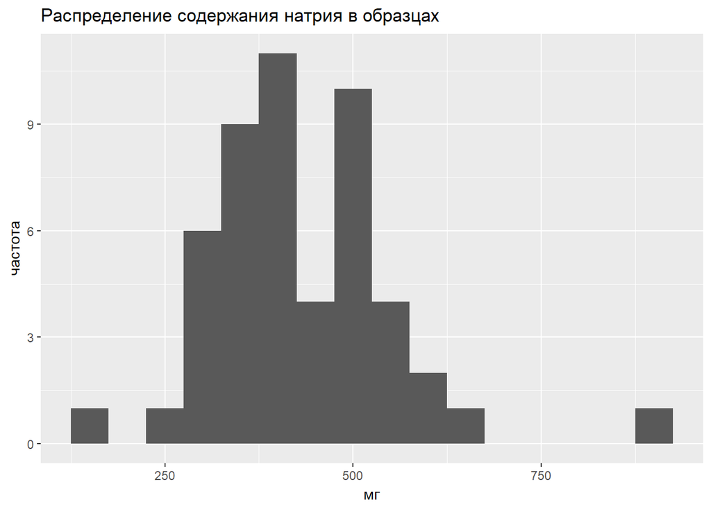

```r
qplot(sodium, data = hotdogs_complete,
      binwidth = 50, # ширина интервала
      main = 'Распределение содержания натрия в образцах',
      xlab = 'мг',
      ylab = 'частота')
```

Видно, что распределение асимметричное и содержит редкие (по 1 наблюдению) очень большие и очень маленькие значения, которые, возможно, являются выбросами.

Распределение также можно визуализировать и с помощью ящичной диаграммы, специально предназначенной для обнаружения аномальных значений.

Для выбора типа графика в `qplot()` используется аргумент `geom = ...`.

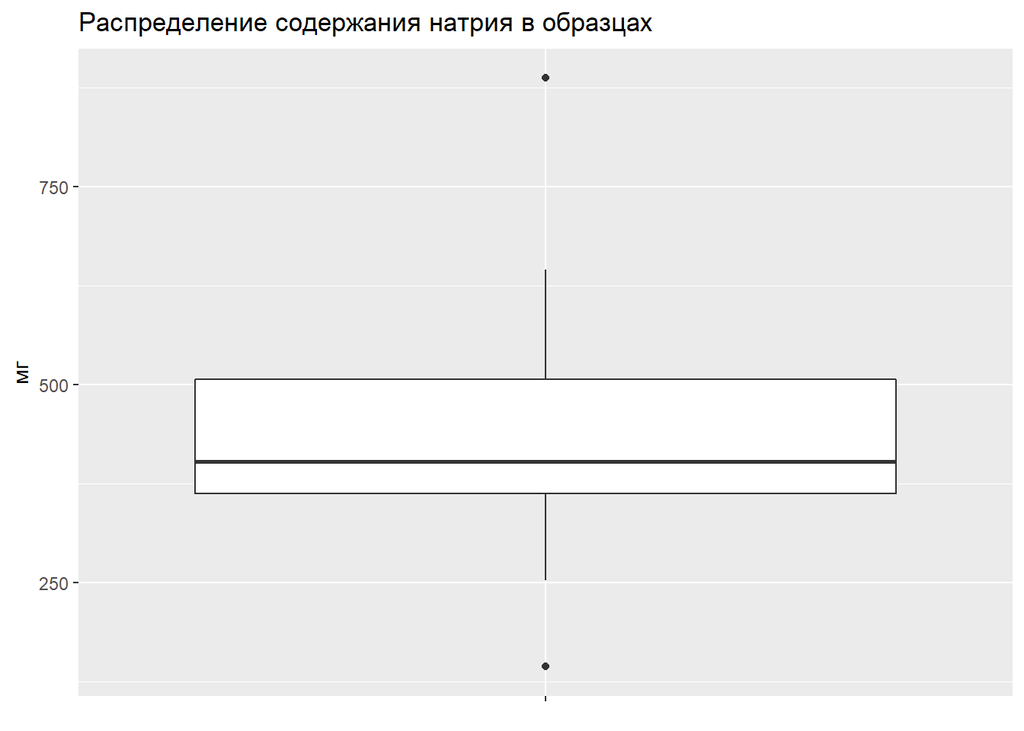

```r
qplot(x = "", y = sodium, data = hotdogs_complete,
      geom = 'boxplot',
      main = 'Распределение содержания натрия в образцах',
      ylab = 'мг',
      xlab = NULL)
```

На ящичной диаграмме хорошо видны два выброса - значения, удаленных от ящика (квартилей) более чем на 1.5 межквартильных размаха.

**Замечание:** обычно ящичные диаграммы используются для сравнения распределений в различных группах. Поэтому в ggplot2 в качестве аргумента `x` для `qplot()` надо обязательно указывать имя столбца, содержащего название группы.

Например, мы могли бы сравнить содержание натрия в хот-догах с разной начинкой.

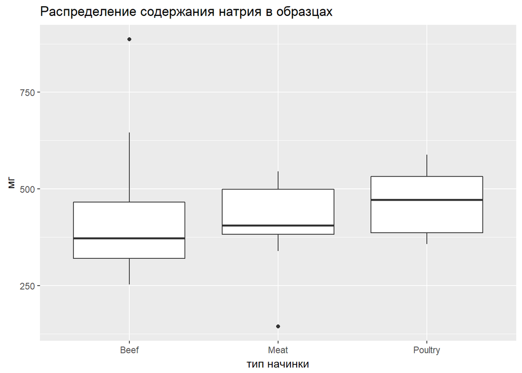

```r
qplot(x = type, y = sodium, data = hotdogs_complete,
      geom = 'boxplot',
      main = 'Распределение содержания натрия в образцах',
      ylab = 'мг',
      xlab = 'тип начинки')
```

В предыдущем примере такое разделение не требовалось, поэтому мы создали фиктивную, безымянную группу: `""`.

Преимуществом использования `qplot()` является возможность строить графики на основе отдельных векторов данных и компактность синтаксиса для получения типовых графиков. Примеры использования функции `qplot()` для построения различных типов графиков можно найти в [руководстве по пакету ggplot2](http://ggplot2.org/book/qplot.pdf).

### Очистка от выбросов

Выбросы в данных могут искажать результаты анализа, т.к. смещают средние значения и коэффициенты моделей. При очистке от выбросов можно применять различные стратегии:

- **удаление** (фильтрация) строк, содержащих выбросы (может привести к большой потере данных)
- **замена на типичные значения** - среднее, медиану
- **винзоризация** (winsorization, по имени изобретателя метода - Чарльза Винзора) - замена аномальных значений, выходящих за некоторый выбранный предел, на ближайшую границу этого предела.

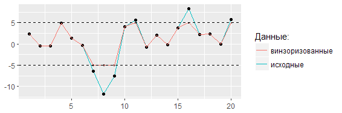

Винзоризация данных

Здесь в качестве примера мы заменим по 2.5% наибольших и наименьших значений содержания натрия на соответствующую границу (квантиль).

Рассчитаем границы интервала допустимых значений:

```r
# Нижняя граница - квантиль 2.5%
min_sodium <-
  quantile(hotdogs_complete$sodium, probs = 0.025, na.rm = TRUE)

# Верхняя граница - квантиль 97.5%
max_sodium <-
  quantile(hotdogs_complete$sodium, probs = 0.975, na.rm = TRUE)

min_sodium
```

```
##    2.5%
## 263.125
```

```r
max_sodium
```

```
##   97.5%
## 632.175
```

Создадим новую таблицу данных с очищенными значениями переменной `sodium`:

```r
hotdogs_cleaned <-
  mutate(hotdogs_complete,
         sodium =
           ifelse(sodium > max_sodium, max_sodium,
                  ifelse(sodium < min_sodium, min_sodium, sodium)))
```

Сравним исходную и очищенную переменные:

```r
# Сводка
summary(hotdogs_complete$sodium)
```

```
##    Min. 1st Qu.  Median    Mean 3rd Qu.    Max.
##   144.0   362.5   403.0   430.1   506.8   887.0
```

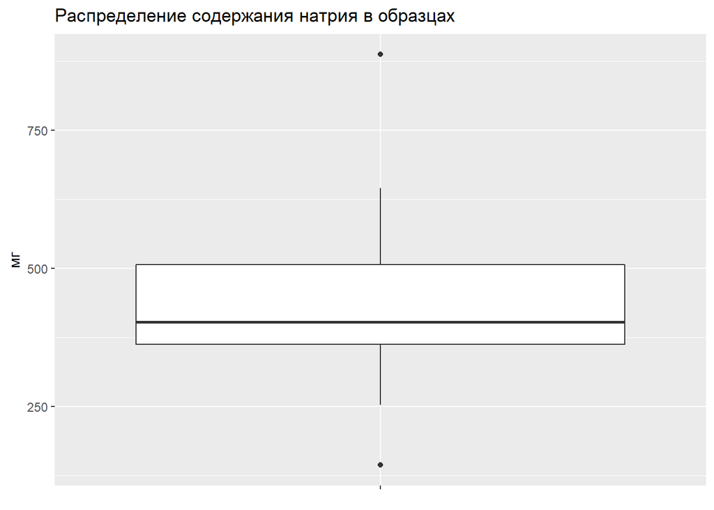

```r
# Ящичная диаграмма
qplot(x = "", y = sodium, data = hotdogs_complete,
      geom = 'boxplot',
      main = 'Распределение содержания натрия в образцах',
      ylab = 'мг',
      xlab = NULL)
```

```r
# Сводка
summary(hotdogs_cleaned$sodium)
```

```
##    Min. 1st Qu.  Median    Mean 3rd Qu.    Max.
##   263.1   362.5   403.0   427.4   506.8   632.2
```

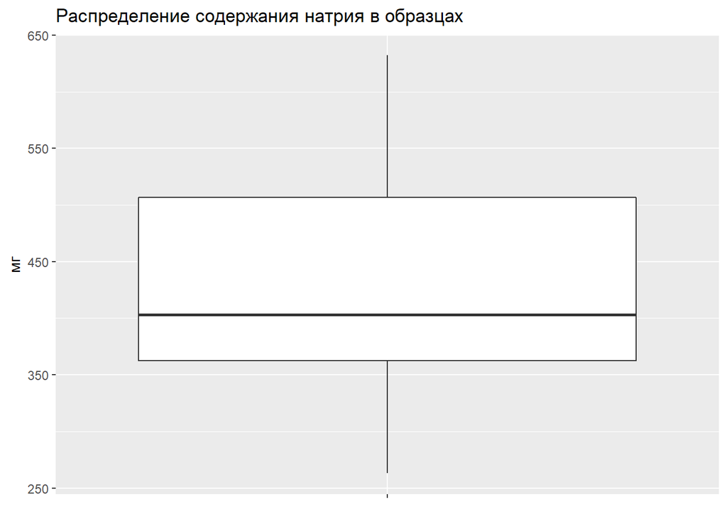

```r
# Ящичная диаграмма
qplot(x = "", y = sodium, data = hotdogs_cleaned,
      geom = 'boxplot',
      main = 'Распределение содержания натрия в образцах',
      ylab = 'мг',
      xlab = NULL)
```

Поскольку мы ранее вычисляли на основе содержания натрия производный столбец - `sodium_ratio`, необходимо пересчитать этот столбец с учетом корректировки значений в столбце `sodium`.

```r
hotdogs_cleaned <-
  mutate(hotdogs_cleaned,
         sodium_ratio = sodium / calories)
```

**Совет:** Проводите очистку данных от пропущенных значений и выбросов как можно раньше, чтобы не переделывать последующие этапы анализа, основанные на затронутых переменных.

## Задание: очистка от выбросов

Постройте ящичную диаграмму и гистограмму для переменной `calories` в наборе данных `hotdogs_cleaned`. Какой из графиков лучше отображает выбросы?

```r
# Гистограмма распределения calories
# qplot(x = ..., data = ...,
#       main = '...',
#       xlab = '...',
#       ylab = '...')

# Гистограмма распределения calories

# qplot(x = "", y = ...,
#       data = ...,
#       geom = '...',
#       ...)
```

Выберите границы диапазона допустимых значений калорийности.

**Замечание:** часто в качестве границ допустимого диапазона значений переменной используют квантили, как мы сделали это в предыдущем примере. Но также возможно задать эти границы вручную, на основе анализа графиков распределения или других соображений.

Напишите код, заменяющий выбросы на **медианное** значение переменной `calories`.

```r
# Рассчитайте медианное значение калорийности:
#med_cal <- ...

# Замените выбросы, выходящие за допустимые границы, на медиану калорийности:
# hotdogs_cleaned <-
#   mutate(...,
#          calories = ...)
```

**Подсказка:** для расчета медианы необходимо воспользоваться функцией `median()`.

**Замечание:** вы можете использовать функцию для расчета медианы прямо в формуле для очищенной переменной. В этом случае создавать временную переменную `med_cal` не придется.

## Задание: заполнение пропущенных значений

Попробуйте восстановить пропущенные значения в таблице `hotdogs`, заменив их на наиболее типичные (средние или медиану) по соответствующей переменной. Результат сохраните в столбцы `<имя переменной>_fixed` в таблице `hotdogs_replaced`.

Выведите на экран только те строки таблицы `hotdogs_replaced`, в которых есть пропуски.

# Приложение 1. Работа с векторами

## Создание вектора вручную

В некоторых случаях векторы приходится вводить вручную. Например, некоторые функции требуют вектор в качестве значения аргумента. Чтобы создать вектор, используйте функцию `c()`:

```r
my_probs <- c(0.1, 0.5, 0.9)
my_probs
```

```
## [1] 0.1 0.5 0.9
```

Мы сохранили вектор в переменную `my_probs` и теперь можем использовать ее в расчетах. Например, в качестве аргумента для функции расчета квантилей:

```r
quantile(hotdogs_complete$sodium_ratio,
         probs = my_probs,
         na.rm = TRUE)
```

```
##      10%      50%      90%
## 2.203772 2.757284 4.200494
```

В данном случае, конечно, можно было и сразу перечислить нужные вероятности при вызове функции `quantile()`:

```r
quantile(hotdogs_complete$sodium_ratio,
         probs = c(0.1, 0.5, 0.9),
         na.rm = TRUE)
```

```
##      10%      50%      90%
## 2.203772 2.757284 4.200494
```

## Извлечение элемента вектора

Извлечь нужные элементы вектора можно по их индексу. R нумерует элементы начиная с 1.

```r
my_probs
```

```
## [1] 0.1 0.5 0.9
```

```r
my_probs[1] # 1-й элемент
```

```
## [1] 0.1
```

```r
my_probs[c(1, 3)] # 1-й и 3-й элементы
```

```
## [1] 0.1 0.9
```

Кроме того, можно извлекать элементы по условию. Условие применяется к каждому элементу, и те, элементы для которых оно истинно, выводятся в результат:

```r
my_probs
```

```
## [1] 0.1 0.5 0.9
```

```r
my_probs > 0.2
```

```
## [1] FALSE  TRUE  TRUE
```

```r
my_probs[my_probs > 0.2]
```

```
## [1] 0.5 0.9
```

## Использование последовательностей

В некоторых случаях требуется создать вектор, представляющий собой последовательность значений с одинаковым шагом. Для этого можно воспользоваться функцией `seq()`.

```r
x_breaks <- seq(0, 900, by = 50)
x_breaks
```

```
##  [1]   0  50 100 150 200 250 300 350 400 450 500 550 600 650 700 750 800
## [18] 850 900
```

Одним из применений последовательностей является настройка делений на осях графиков.

Сравним гистограмму, которую строили до этого с автоподбором цены деления на оси x, и гистограмму с явно заданными делениями.

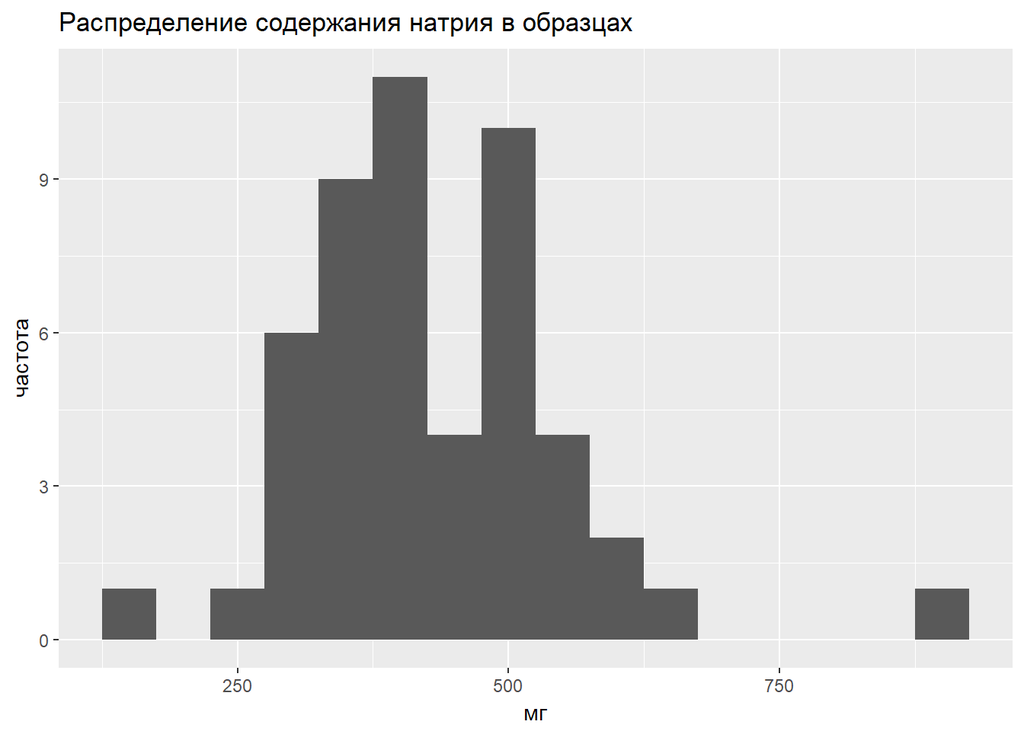

```r
# Автоподбор
qplot(sodium, data = hotdogs_complete,
      binwidth = 50, # ширина интервала
      main = 'Распределение содержания натрия в образцах',
      xlab = 'мг',
      ylab = 'частота')
```

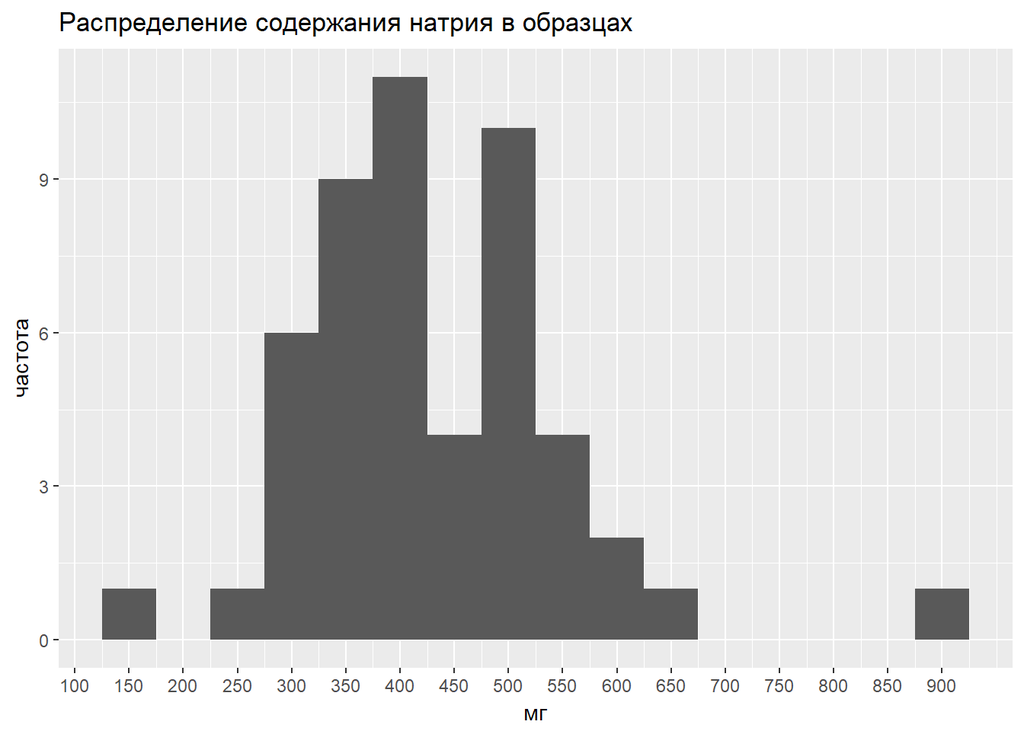

```r
# Указание вручную
qplot(sodium, data = hotdogs_complete,
      binwidth = 50, # ширина интервала
      main = 'Распределение содержания натрия в образцах',
      xlab = 'мг',
      ylab = 'частота') +
  scale_x_continuous(breaks = x_breaks)
```

Для последовательностей с единичным шагом можно использовать краткую запись:

```r
5:10
```

```
## [1]  5  6  7  8  9 10
```

## Объединение векторов в таблицу данных

В некоторых случаях требуется объединить несколько векторов и создать из них таблицу данных. Например, функция `ggplot()` может работать только с табличными данными.

В качестве примера создадим два случайных вектора и сделаем из них таблицу данных. Мы будем использовать современный тип таблиц - `tibble`. Классический `data.frame` создается аналогичным образом.

```r
set.seed(12345) # инициализируем генератор случайных чисел для воспроизводимости
rx <- rnorm(n = 10000, mean = 100, sd = 20)
ry <- rnorm(n = 10000, mean = 100, sd = 20)

my_table <- tibble(x = rx, y = ry) # <имя столбца> = <имя вектора>

head(my_table)
```

```
## # A tibble: 6 x 2
##           x         y
##       <dbl>     <dbl>
## 1 111.71058 103.22555
## 2 114.18932 110.63843
## 3  97.81393  74.04193
## 4  90.93006 124.91157
## 5 112.11775  80.16619
## 6  63.64088  93.63614
```

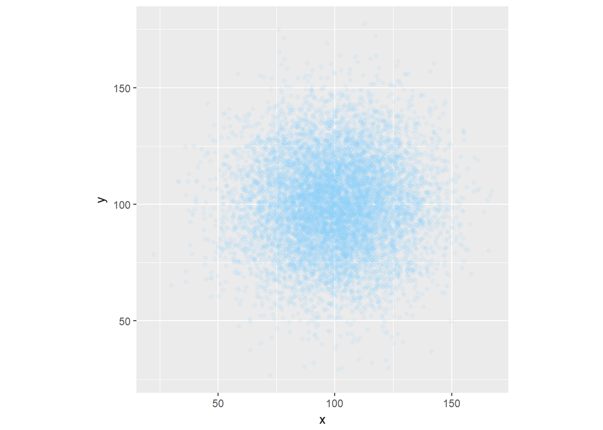

```r
ggplot(data = my_table, aes(x, y)) +
  geom_point(alpha = 0.1, color = 'lightskyblue') +
  coord_fixed() # одинаковый масштаб по x и y
```

# Приложение 2. Работа со списками

Векторы в R могут содержать значения любого типа, однако этот тип должен быть одинаковым у всех элементов вектора. Для обработки разнотипных элементов используются **списки** (list). Элементами списка могут быть любые объекты, в т.ч. векторы и другие списки. Векторизованные операции со списками напрямую не поддерживаются, однако их можно обрабатывать с помощью функций базового R: `*apply()` и функций из пакета `purrr`.

## Создание списка

Для создания списков используется функция `list()`.

```r
inner_list <- list(11, 'A', TRUE)
inner_list
```

```
## [[1]]
## [1] 11
##
## [[2]]
## [1] "A"
##
## [[3]]
## [1] TRUE
```

## Извлечение элементов из списка

При извлечении элемента списка `[]` возвращает единичный список, содержащий элемент по указанному индексу, а `[[]]` - сам этот элемент.

```r
inner_list[2]
```

```
## [[1]]
## [1] "A"
```

```r
inner_list[[2]]
```

```
## [1] "A"
```

[figure not shown]

Иллюстрация работы с элементами списка

## Именованные списки

В R у элементов векторов и списков могут быть имена. Эти имена можно вместо индексов использовать для извлечения элементов.

```r
named_list <- list(first = inner_list, second = 1:5, third = pi)
named_list
```

```
## $first
## $first[[1]]
## [1] 11
##
## $first[[2]]
## [1] "A"
##
## $first[[3]]
## [1] TRUE
##
##
## $second
## [1] 1 2 3 4 5
##
## $third
## [1] 3.141593
```

Структуру списка можно изучить при помощи функций `names()` и `str()`.

Какие элементы есть в списке?

```r
names(named_list)
```

```
## [1] "first"  "second" "third"
```

Развернутая структура списка.

```r
str(named_list)
```

```
## List of 3
##  $ first :List of 3
##   ..$ : num 11
##   ..$ : chr "A"
##   ..$ : logi TRUE
##  $ second: int [1:5] 1 2 3 4 5
##  $ third : num 3.14
```

```r
named_list[['third']]
```

```
## [1] 3.141593
```

```r
named_list$third
```

```
## [1] 3.141593
```

```r
my_args <- list(from = 1, to = 10, by = 2)
seq(my_args)
```

```
## [1] 1 2 3
```

## Объекты R - это списки

Умение работать со списками важно, поскольку объекты в R - например, модели, графики ggplot2, таблицы данных - хранятся в виде списков.

В качестве примера построим модель зависимости содержания натрия от калорийности и исследуем ее тип и структуру.

```r
# Полученная модель сохраняется в виде списка
m_sodium <- lm(sodium ~ calories, data = hotdogs_complete)

# Какие имена доступны
names(m_sodium)
```

```
##  [1] "coefficients"  "residuals"     "effects"       "rank"
##  [5] "fitted.values" "assign"        "qr"            "df.residual"
##  [9] "xlevels"       "call"          "terms"         "model"
```

Зная имена элементов объекта, можно их извлечь и использовать в расчетах.

```r
# Получим вектор коэффициентов модели
m_sodium$coefficients
```

```
## (Intercept)    calories
##  219.360364    1.470692
```

Добавим на диаграмму рассеяния линию тренда с использованием полученных коэффициентов.

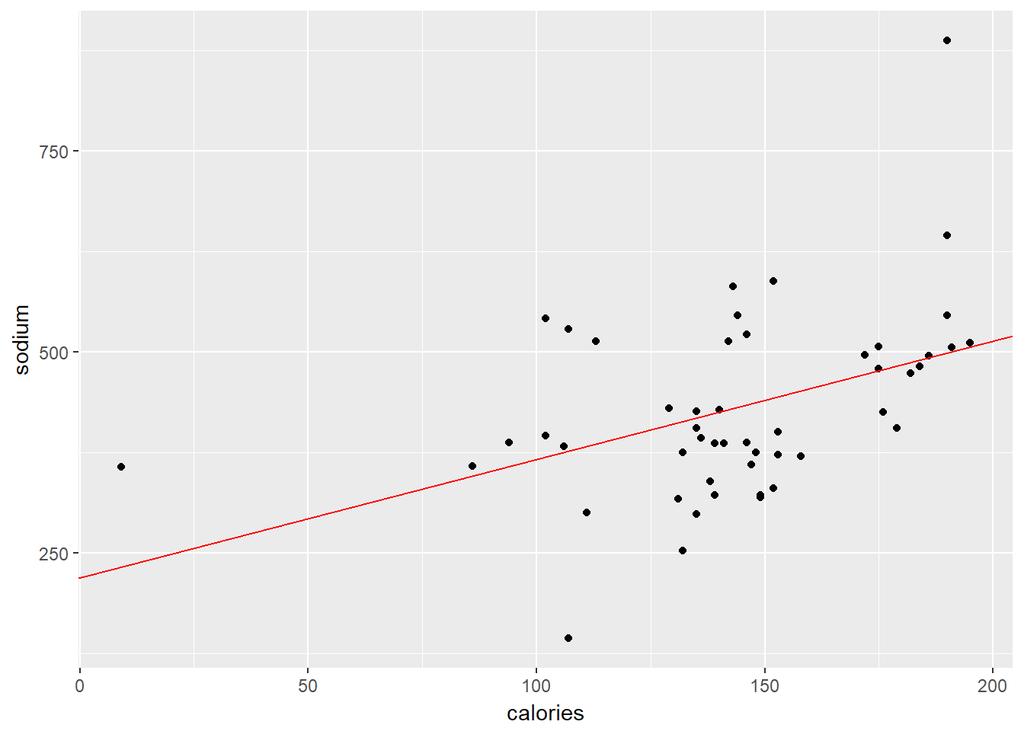

```r
qplot(x = calories, y = sodium, data = hotdogs_complete) +
  geom_abline(intercept = m_sodium$coefficients['(Intercept)'],
              slope = m_sodium$coefficients['calories'],
              color = 'red')
```

Подробно изучить структуру объекта можно с помощью функции `str()` или панели `Global Environment` в RStudio.

# Приложение 3. Отбор столбцов таблицы с помощью индексов

Полезно знать, как работать с таблицами стандартными средствами R.

```r
high_sodium[ , c(1, 4)]
```

```
## # A tibble: 7 x 2
##      type sodium_ratio
##     <chr>        <dbl>
## 1 Poultry     4.117021
## 2 Poultry     5.313725
## 3 Poultry    39.666667
## 4 Poultry     4.934579
## 5 Poultry     4.539823
## 6 Poultry     4.162791
## 7 Poultry     4.062937
```

Здесь `c()` - функция для создания вектора с номерами нужных столбцов.

Добавив `-`, можно извлечь все кроме указанных столбцов.

```r
high_sodium[ , -c(2, 3)]
```

```
## # A tibble: 7 x 3
##      type sodium_ratio kilojoules
##     <chr>        <dbl>      <dbl>
## 1 Poultry     4.117021    393.296
## 2 Poultry     5.313725    426.768
## 3 Poultry    39.666667     37.656
## 4 Poultry     4.934579    447.688
## 5 Poultry     4.539823    472.792
## 6 Poultry     4.162791    359.824
## 7 Poultry     4.062937    598.312
```

Поскольку структура данных может со временем меняться, очень опасно отбирать элементы таблицы по номерам. Если нумерация поменяется, то ваш скрипт будет обрабатывать неправильные данные. Это может незаметно исказить результаты анализа. Лучше всегда использовать имена.

```r
high_sodium[ , c('type', 'sodium_ratio')]
```

```
## # A tibble: 7 x 2
##      type sodium_ratio
##     <chr>        <dbl>
## 1 Poultry     4.117021
## 2 Poultry     5.313725
## 3 Poultry    39.666667
## 4 Poultry     4.934579
## 5 Poultry     4.539823
## 6 Poultry     4.162791
## 7 Poultry     4.062937
```